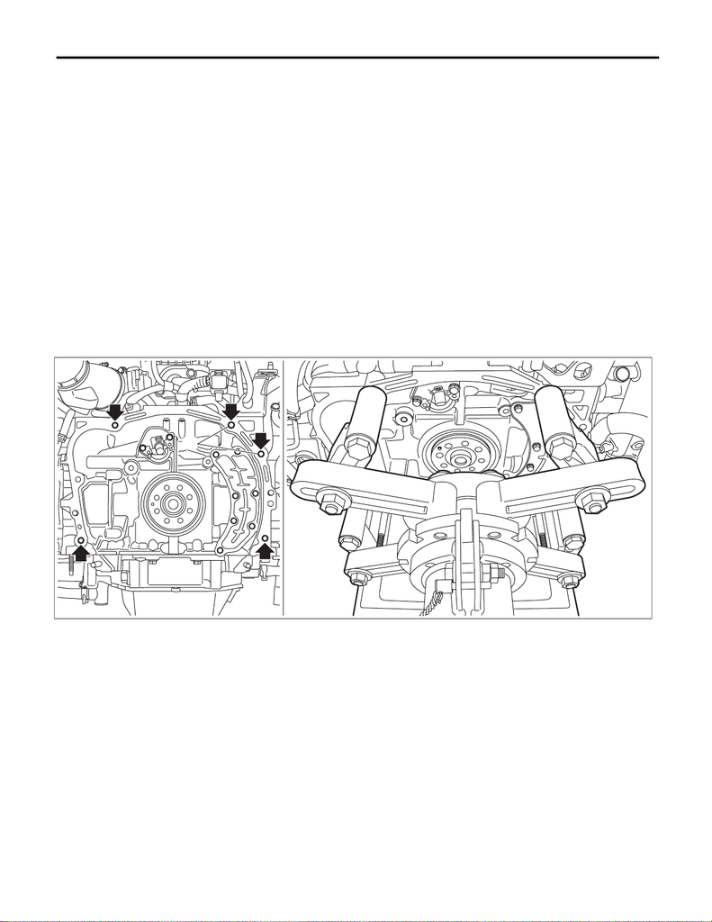

ME(w/o STI)-77

Preparation for Overhaul

MECHANICAL

11.Preparation for Overhaul

A: PROCEDURE

1) After engine has been removed from the vehicle, mount the engine to the engine stand while being careful

of the following.

(1) When mounting the engine stand, follow the instructions of engine stand used.

(2) When disassembling the cylinder block, remove the following parts first, and then mount the engine

stand.

1. Remove the crankshaft position sensor plate with drive plate. (CVT model) <Ref. to CVT(TR690)-137,

REMOVAL, Drive Plate.>

2. Remove the clutch disc and cover. (MT model) <Ref. to CL-12, REMOVAL, Clutch Disc and Cover.>

3. Remove the crankshaft position sensor plate with flywheel. (MT model) <Ref. to CL-15, REMOVAL, Fly-

wheel.>

(3) Mount the engine stand using the points shown by the arrows in the figure.

CAUTION:

NOTE:

• The engine stand shown in the figure is just for reference.

2) In this section the procedures described under each index are all connected and stated in order. The pro-

cedure for overhauling of the engine will be completed when you go through all steps in the process.

Therefore, in this section, to conduct the particular procedure within the flow of a section, you need to go back

and conduct the procedure described previously in order to do that particular procedure.

ME-06601

(A)